# Sounds of the Jungle

Extracting sounds of individual animals from an audio recording of the jungle by applying Fast Fourier Transform (FFT), filtering and analysing spectrograms.

```python
import pandas as pd
from matplotlib import pyplot as plt
import seaborn as sns
import numpy as np
from numpy.fft import fft, ifft
from numpy.fft import fftshift
from numpy.fft import ifftshift
import matplotlib as mpl
mpl.rcParams['figure.dpi'] = 100
from scipy import signal
from scipy.io import wavfile
import IPython.display as ipd
```

- Load file './Jungle-SoundBible.com-1211567897.wav'
- Listen to the file and and plot the **time series**, **the spectrum**, and **the spectrogram**

```python
# Please implement
sample_rate, data = wavfile.read('./Jungle-SoundBible.com-1211567897.wav')
data = data[:,0]

number_of_samples = len(data)
length_in_seconds = len(data)/sample_rate
print("number of samples:", number_of_samples)
print("length in seconds:", length_in_seconds)
print("samples per second:", sample_rate)

ipd.Audio(data, rate = sample_rate )
```

```
number of samples: 119808
length in seconds: 5.433469387755102
samples per second: 22050
```

[interactive chart not shown]

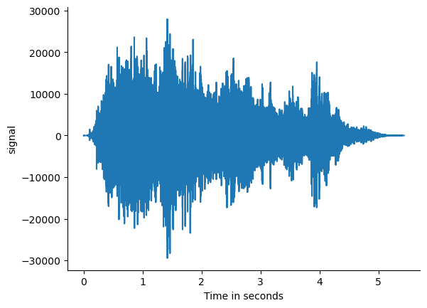

```python
# time series
x = np.arange(number_of_samples) / sample_rate
plt.plot(x, data)
plt.xlabel('Time in seconds')
plt.ylabel('signal')
sns.despine()
```

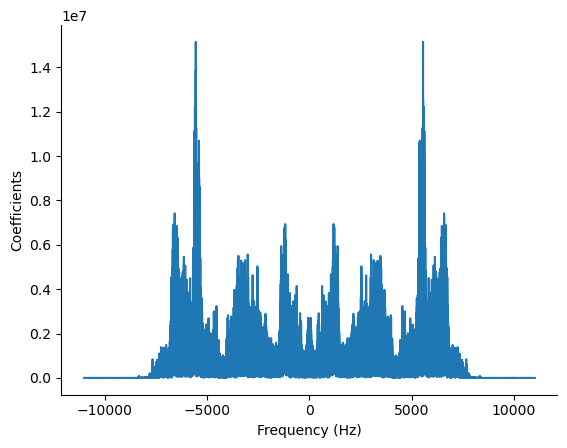

```python
# spectrum
signal_ = data
signalFFT = fftshift(fft(signal_))

freqs = np.arange(signal_.size)

# zero frequency is in the centre
freqs = freqs - (signal_.size)//2

# Obtain frequency in Hz
freqsSecs = freqs/(signal_.size/sample_rate)

sns.lineplot(x = freqsSecs, y = np.abs(signalFFT))
plt.ylabel('Coefficients')
plt.xlabel('Frequency (Hz)')
sns.despine()
```

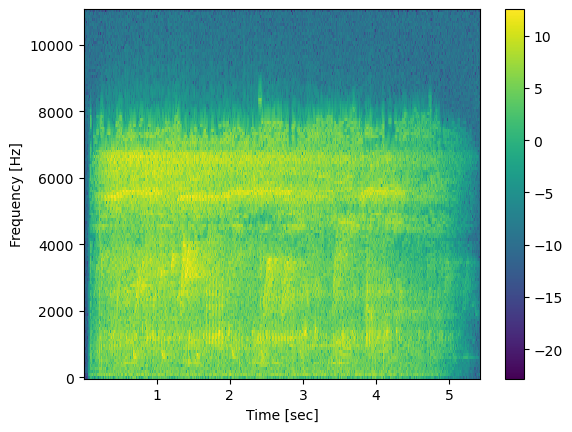

```python
# spectrogram
f, t, Sxx = signal.spectrogram(signal_, sample_rate)

plt.pcolormesh(t, f, np.log(Sxx))
plt.xlabel('Time [sec]')
plt.ylabel('Frequency [Hz]')
plt.colorbar()
plt.show()
```

- Identifying which parts of spectrum belong to different animals
- Designing 3 different wall filters to isolate the sound produced by 3 types of animal
- After filtering the signal, making a spectrogram for each filtered signal

#### Observations from Spectrum:

- Animal 1: 200Hz to 1600Hz ?
- Animal 2: 1800Hz to 4100Hz ?
- Animal 3: 4400Hz to 7200Hz ?

**Zooming in on the spectrogram below to find the correct parts of the spectrum:**

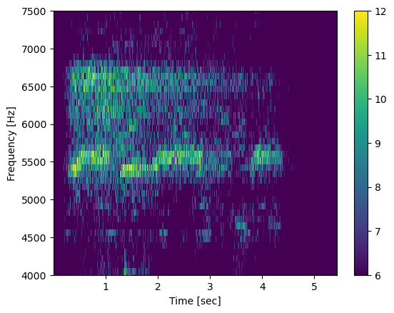

```python
# Check spectrum observations with spectrogram
# expect to find high intesnity regions between the 3 frequency ranges above
f, t, Sxx = signal.spectrogram(signal_, sample_rate)

# modify vmin, vmax to change intensity scale
plt.pcolormesh(t, f, np.log(Sxx), vmin=6, vmax=12)
plt.ylabel('Frequency [Hz]')
plt.xlabel('Time [sec]')
# plt.ylim(200,2000) # updated range for animal 1: 1000Hz-1500Hz
# plt.ylim(1600,4400) # updated range for animal 2: 3000Hz-4000Hz
plt.ylim(4000,7500) # updated range for animal 3: 5300Hz-5800Hz

plt.colorbar()
plt.show()
```

### Observations from Spectrum & Spectrogram:

Updated observations after analysing spectrogram.

- Animal 1: 1000Hz to 1500Hz
- Animal 2: 3000Hz to 4000Hz
- Animal 3: 5300Hz to 5800Hz

### Filters

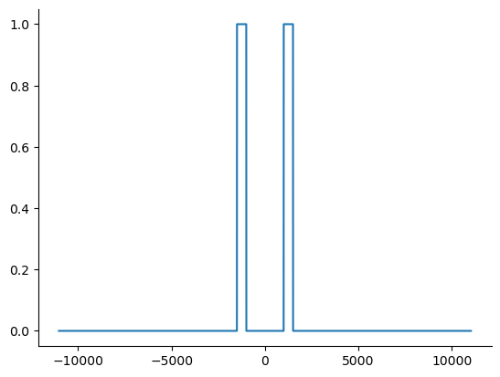

```python
# Filter 1
# 1000 to 1500Hz
minf, maxf = 1000, 1500

tmp_length = len(freqsSecs)//2

negative_weights = np.ones(tmp_length)
negative_weights[(freqsSecs[0:tmp_length]<-maxf)] = 0
negative_weights[(freqsSecs[0:tmp_length]>-minf)] = 0

positive_weights = np.ones(tmp_length)
positive_weights[(freqsSecs[tmp_length:]>maxf)] = 0
positive_weights[(freqsSecs[tmp_length:]<minf)] = 0

weights_1 = np.append(negative_weights,positive_weights)

plt.plot(freqsSecs, weights_1)
sns.despine()
```

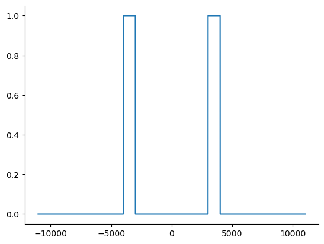

```python
# Filter 2
# 3000 to 4000Hz
minf, maxf = 3000, 4000

tmp_length = len(freqsSecs)//2

negative_weights = np.ones(tmp_length)
negative_weights[(freqsSecs[0:tmp_length]<-maxf)] = 0
negative_weights[(freqsSecs[0:tmp_length]>-minf)] = 0

positive_weights = np.ones(tmp_length)
positive_weights[(freqsSecs[tmp_length:]>maxf)] = 0
positive_weights[(freqsSecs[tmp_length:]<minf)] = 0

weights_2 = np.append(negative_weights,positive_weights)
plt.plot(freqsSecs, weights_2)
sns.despine()
```

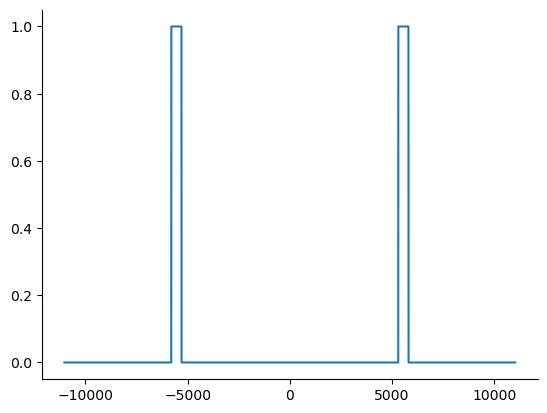

```python
# Filter 3
# 5300 to 5800Hz
minf, maxf = 5300, 5800

tmp_length = len(freqsSecs)//2

negative_weights = np.ones(tmp_length)
negative_weights[(freqsSecs[0:tmp_length]<-maxf)] = 0
negative_weights[(freqsSecs[0:tmp_length]>-minf)] = 0

positive_weights = np.ones(tmp_length)
positive_weights[(freqsSecs[tmp_length:]>maxf)] = 0
positive_weights[(freqsSecs[tmp_length:]<minf)] = 0

weights_3 = np.append(negative_weights,positive_weights)
plt.plot(freqsSecs, weights_3)
sns.despine()
```

#### Applying Filters:

```python
# Applying Filter 1
signalFFT1_filtered = signalFFT*weights_1
# spectrum_plot(freqsSecs,np.abs(signalFFT1_filtered),xmin=0,xmax=11000,ymin=-0.05e7,ymax=1.6e7)

signalFFT1_shiftback = ifftshift(signalFFT1_filtered)
signalFFT1_reconstructed = ifft(signalFFT1_shiftback)
signalFFT1_reconstructed = signalFFT1_reconstructed.real

ipd.Audio(signalFFT1_reconstructed, rate = sample_rate )
# Sounds like a frog
```

[interactive chart not shown]

```python
# Applying Filter 2
signalFFT2_filtered = signalFFT*weights_2
# spectrum_plot(freqsSecs,np.abs(signalFFT2_filtered),xmin=0,xmax=11000,ymin=-0.05e7,ymax=1.6e7)

signalFFT2_shiftback = ifftshift(signalFFT2_filtered)
signalFFT2_reconstructed = ifft(signalFFT2_shiftback)
signalFFT2_reconstructed = signalFFT2_reconstructed.real

ipd.Audio(signalFFT2_reconstructed, rate = sample_rate )
# Sounds like a bird
```

[interactive chart not shown]

```python
# Applying Filter 3
signalFFT3_filtered = signalFFT*weights_3
# spectrum_plot(freqsSecs,np.abs(signalFFT3_filtered),xmin=0,xmax=11000,ymin=-0.05e7,ymax=1.6e7)

signalFFT3_shiftback = ifftshift(signalFFT3_filtered)
signalFFT3_reconstructed = ifft(signalFFT3_shiftback)
signalFFT3_reconstructed = signalFFT3_reconstructed.real

ipd.Audio(signalFFT3_reconstructed, rate = sample_rate )
# Sounds like crickets
```

[interactive chart not shown]

#### Spectrograms for each filtered animal:

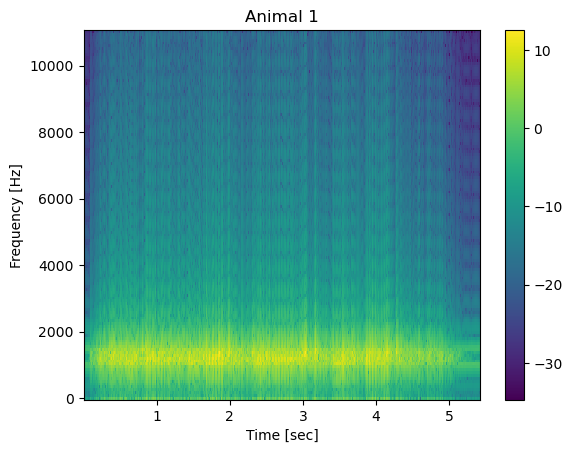

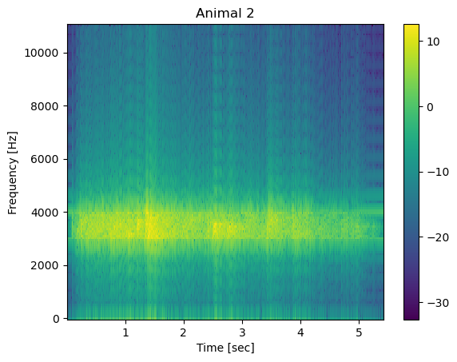

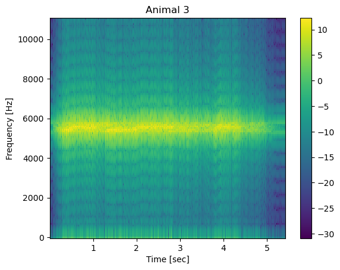

```python
def spectrogram_plot(reconstructed_signal,sample_rate,title):
    f, t, Sxx = signal.spectrogram(reconstructed_signal, sample_rate)
    plt.pcolormesh(t, f, np.log(Sxx))
    plt.ylabel('Frequency [Hz]')
    plt.xlabel('Time [sec]')
    plt.title(title)
    plt.colorbar()
    plt.show()

# Animal 1
spectrogram_plot(signalFFT1_reconstructed,sample_rate,title='Animal 1')

# Animal 2
spectrogram_plot(signalFFT2_reconstructed,sample_rate,title='Animal 2')

# Animal 3
spectrogram_plot(signalFFT3_reconstructed,sample_rate,title='Animal 3')
```

- Applying a smooth (Gaussian) filter for animal 2 above to see if sound quality for the animal's noise can be improved by smoother transitions between areas of the spectrum to be retained or removed.

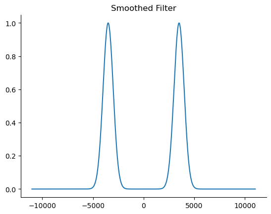

```python
# Please implement

# Smooth (Gaussian) filter for animal 2 above

minf = 3000
maxf = 4000

mu = minf + (maxf-minf)/2
sigma = (maxf-minf)/2

tmp_length = len(freqsSecs)//2

negative_smooth_weights = np.exp(-((freqsSecs[0:tmp_length]-(-mu))**2)/(2*sigma**2))
positive_smooth_weights = np.exp(-((freqsSecs[tmp_length:]-mu)**2)/(2*sigma**2))
smooth_weights = np.append(negative_smooth_weights,positive_smooth_weights)

plt.plot(freqsSecs, smooth_weights)
plt.title("Smoothed Filter")
sns.despine()
```

```python
# Applying Smooth Filter
signalFFT_filtered = signalFFT*smooth_weights
# spectrum_plot(freqsSecs,np.abs(signalFFT2_filtered),xmin=0,xmax=11000,ymin=-0.05e7,ymax=1.6e7)

signalFFT_shiftback= ifftshift(signalFFT_filtered)
signalFFT_reconstructed = ifft(signalFFT_shiftback)
signalFFT_reconstructed = signalFFT_reconstructed.real

ipd.Audio(signalFFT_reconstructed, rate = sample_rate )
# Sounds like a bird
```

[interactive chart not shown]

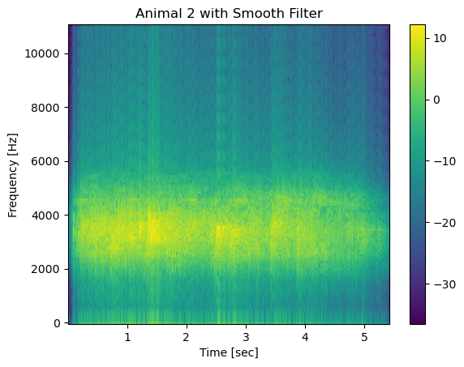

```python
# Spectrogram after filtering with smooth filter
title = 'Animal 2 with Smooth Filter'
spectrogram_plot(signalFFT_reconstructed,sample_rate,title)
```